# EDA_ML_Loan_Dataset

## **EDA and Predication - Loan Dataset**

### Problem Statement

- The goal is to predict whether loan can be sanctioned or not.

```python
#Importing all required libraries for EDA
import numpy as np                                                 # Implemennts milti-dimensional array and matrices
import pandas as pd                                                # For data manipulation and analysis
import pandas_profiling
import matplotlib.pyplot as plt                                    # Plotting library for Python programming language and it's numerical mathematics extension NumPy
import seaborn as sns                                              # Provides a high level interface for drawing attractive and informative statistical graphics
%matplotlib inline
sns.set()

from subprocess import check_output
```

```python
dataset = pd.read_csv("G:\machine_learning\SBAnational.csv")
dataset
```

|  | LoanNr_ChkDgt | Name | City | State | Zip | Bank | BankState | NAICS | ApprovalDate | ApprovalFY | ... | RevLineCr | LowDoc | ChgOffDate | DisbursementDate | DisbursementGross | BalanceGross | MIS_Status | ChgOffPrinGr | GrAppv | SBA_Appv |
| --- | --- | --- | --- | --- | --- | --- | --- | --- | --- | --- | --- | --- | --- | --- | --- | --- | --- | --- | --- | --- | --- |
| 0 | 1000014003 | ABC HOBBYCRAFT | EVANSVILLE | IN | 47711 | FIFTH THIRD BANK | OH | 451120 | 28-Feb-97 | 1997 | ... | N | Y | NaN | 28-Feb-99 | $60,000.00 | $0.00 | P I F | $0.00 | $60,000.00 | $48,000.00 |
| 1 | 1000024006 | LANDMARK BAR & GRILLE (THE) | NEW PARIS | IN | 46526 | 1ST SOURCE BANK | IN | 722410 | 28-Feb-97 | 1997 | ... | N | Y | NaN | 31-May-97 | $40,000.00 | $0.00 | P I F | $0.00 | $40,000.00 | $32,000.00 |
| 2 | 1000034009 | WHITLOCK DDS, TODD M. | BLOOMINGTON | IN | 47401 | GRANT COUNTY STATE BANK | IN | 621210 | 28-Feb-97 | 1997 | ... | N | N | NaN | 31-Dec-97 | $287,000.00 | $0.00 | P I F | $0.00 | $287,000.00 | $215,250.00 |
| 3 | 1000044001 | BIG BUCKS PAWN & JEWELRY, LLC | BROKEN ARROW | OK | 74012 | 1ST NATL BK & TR CO OF BROKEN | OK | 0 | 28-Feb-97 | 1997 | ... | N | Y | NaN | 30-Jun-97 | $35,000.00 | $0.00 | P I F | $0.00 | $35,000.00 | $28,000.00 |
| 4 | 1000054004 | ANASTASIA CONFECTIONS, INC. | ORLANDO | FL | 32801 | FLORIDA BUS. DEVEL CORP | FL | 0 | 28-Feb-97 | 1997 | ... | N | N | NaN | 14-May-97 | $229,000.00 | $0.00 | P I F | $0.00 | $229,000.00 | $229,000.00 |
| 5 | 1000084002 | B&T SCREW MACHINE COMPANY, INC | PLAINVILLE | CT | 6062 | TD BANK, NATIONAL ASSOCIATION | DE | 332721 | 28-Feb-97 | 1997 | ... | N | N | NaN | 30-Jun-97 | $517,000.00 | $0.00 | P I F | $0.00 | $517,000.00 | $387,750.00 |
| 6 | 1000093009 | MIDDLE ATLANTIC SPORTS CO INC | UNION | NJ | 7083 | WELLS FARGO BANK NATL ASSOC | SD | 0 | 2-Jun-80 | 1980 | ... | N | N | 24-Jun-91 | 22-Jul-80 | $600,000.00 | $0.00 | CHGOFF | $208,959.00 | $600,000.00 | $499,998.00 |
| 7 | 1000094005 | WEAVER PRODUCTS | SUMMERFIELD | FL | 34491 | REGIONS BANK | AL | 811118 | 28-Feb-97 | 1997 | ... | N | Y | NaN | 30-Jun-98 | $45,000.00 | $0.00 | P I F | $0.00 | $45,000.00 | $36,000.00 |
| 8 | 1000104006 | TURTLE BEACH INN | PORT SAINT JOE | FL | 32456 | CENTENNIAL BANK | FL | 721310 | 28-Feb-97 | 1997 | ... | N | N | NaN | 31-Jul-97 | $305,000.00 | $0.00 | P I F | $0.00 | $305,000.00 | $228,750.00 |
| 9 | 1000124001 | INTEXT BUILDING SYS LLC | GLASTONBURY | CT | 6073 | WEBSTER BANK NATL ASSOC | CT | 0 | 28-Feb-97 | 1997 | ... | N | Y | NaN | 30-Apr-97 | $70,000.00 | $0.00 | P I F | $0.00 | $70,000.00 | $56,000.00 |
| 10 | 1000134004 | COMMERCIAL TRUCKING MAINTENANC | CHARLOTTE | NC | 28256 | SUNTRUST BANK | GA | 811111 | 28-Feb-97 | 1997 | ... | N | Y | NaN | 23-Feb-98 | $70,000.00 | $0.00 | P I F | $0.00 | $70,000.00 | $56,000.00 |
| 11 | 1000144007 | PROFESSIONAL ELEVATOR SERVICES | CHICAGO | IL | 60605 | BANK OF AMERICA NATL ASSOC | OR | 235950 | 28-Feb-97 | 1997 | ... | N | N | NaN | 30-Nov-97 | $150,000.00 | $0.00 | P I F | $0.00 | $300,000.00 | $225,000.00 |
| 12 | 1000146010 | CARVEL | APEX | NC | 27502 | STEARNS BK NATL ASSOC | MN | 445299 | 7-Feb-06 | 2006 | ... | N | N | NaN | 31-Mar-06 | $253,400.00 | $0.00 | P I F | $0.00 | $253,400.00 | $190,050.00 |
| 13 | 1000154010 | ORCHARD CAFE & BAKERY, INC. | SLATERSVILLE | RI | 2876 | CITIZENS BANK NATL ASSOC | RI | 0 | 28-Feb-97 | 1997 | ... | N | N | NaN | 31-May-97 | $370,000.00 | $0.00 | P I F | $0.00 | $370,000.00 | $277,500.00 |
| 14 | 1000214004 | EBC INVESTMENTS LLC | WINSTON-SALEM | NC | 27106 | NORTHWEST PIEDMONT DEVEL CORPO | NC | 0 | 28-Feb-97 | 1997 | ... | N | N | NaN | 17-Dec-97 | $225,000.00 | $0.00 | P I F | $0.00 | $225,000.00 | $225,000.00 |
| 15 | 1000244002 | ENVIRONMENTAL ROOFING SYSTEMS, | OKLAHOMA CITY | OK | 73112 | BANK OF AMERICA NATL ASSOC | NC | 421330 | 28-Feb-97 | 1997 | ... | N | N | NaN | 30-Sep-97 | $350,000.00 | $0.00 | P I F | $0.00 | $350,000.00 | $262,500.00 |
| 16 | 1000254005 | ARK MAMAGEMENT ENTERPRISES INC | MIDLAND | TX | 79701 | WELLS FARGO BANK NATL ASSOC | TX | 0 | 28-Feb-97 | 1997 | ... | N | Y | NaN | 30-Jun-97 | $70,000.00 | $0.00 | P I F | $0.00 | $70,000.00 | $56,000.00 |
| 17 | 1000264008 | FAIRFAX COURT SUBWAY, INC. | CENTREVILLE | VA | 20120 | BANK OF AMERICA NATL ASSOC | MD | 0 | 28-Feb-97 | 1997 | ... | N | Y | NaN | 31-Jul-97 | $100,000.00 | $0.00 | P I F | $0.00 | $100,000.00 | $80,000.00 |
| 18 | 1000284003 | FANTASTIC SAMS | PLANO | TX | 75093 | NEWTEK SMALL BUS. FINANCE INC. | NY | 0 | 28-Feb-97 | 1997 | ... | N | Y | NaN | 31-May-97 | $57,500.00 | $0.00 | P I F | $0.00 | $57,500.00 | $46,000.00 |
| 19 | 1000294006 | SIR GOONY'S GOLF | KNOXVILLE | TN | 37922 | CITIZENS NATIONAL BANK | TN | 0 | 28-Feb-97 | 1997 | ... | N | Y | NaN | 31-May-98 | $50,000.00 | $0.00 | P I F | $0.00 | $50,000.00 | $40,000.00 |
| 20 | 1000324002 | ECONOLODGE OF DUMAS | DUMAS | TX | 79029 | BUSINESS LOAN CENTER, LLC | SC | 0 | 28-Feb-97 | 1997 | ... | N | N | NaN | 30-Apr-97 | $615,000.00 | $0.00 | P I F | $0.00 | $615,000.00 | $461,250.00 |
| 21 | 1000344008 | YOUNG ACHIEVERS PRESCHOOL, INC | CORAL SPRINGS | FL | 33065 | BANESCO USA | FL | 624410 | 28-Feb-97 | 1997 | ... | N | N | NaN | 31-Aug-97 | $70,000.00 | $0.00 | P I F | $0.00 | $70,000.00 | $56,000.00 |
| 22 | 1000394001 | NICOLES RESTAURANT | JOHNSTON | RI | 2919 | BANK OF AMERICA NATL ASSOC | RI | 0 | 28-Feb-97 | 1997 | ... | N | N | NaN | 31-Mar-98 | $75,000.00 | $0.00 | P I F | $0.00 | $75,000.00 | $56,250.00 |
| 23 | 1000434000 | TRIANGLE MACHINE & MFG., INC. | EULESS | TX | 76040 | FIRST BANK TEXAS, SSB | TX | 0 | 28-Feb-97 | 1997 | ... | N | N | NaN | 30-Apr-97 | $1,250,000.00 | $0.00 | P I F | $0.00 | $1,250,000.00 | $937,500.00 |
| 24 | 1000446006 | SUBWAY | LITTLE ROCK | AR | 72223 | HOPE FCU | MS | 722211 | 7-Feb-06 | 2006 | ... | N | N | NaN | 30-Apr-06 | $137,300.00 | $0.00 | P I F | $0.00 | $137,300.00 | $116,705.00 |
| 25 | 1000474001 | DEE'S CORNER BAIT & TACKLE | SAINT PETER | MN | 56082 | WELLS FARGO BANK NATL ASSOC | MN | 451110 | 28-Feb-97 | 1997 | ... | N | N | NaN | 30-Apr-97 | $39,500.00 | $0.00 | P I F | $0.00 | $39,500.00 | $29,625.00 |
| 26 | 1000484004 | C & S TRANSIT, INC. | INDEPENDENCE | MO | 64055 | BANK OF AMERICA NATL ASSOC | NC | 0 | 28-Feb-97 | 1997 | ... | 0 | N | NaN | 31-May-98 | $50,000.00 | $0.00 | P I F | $0.00 | $50,000.00 | $25,000.00 |
| 27 | 1000504008 | HUNTERSBROOK STABLE | MARSHFIELD | MA | 2050 | ROCKLAND TRUST COMPANY | MA | 0 | 28-Feb-97 | 1997 | ... | N | Y | NaN | 31-Jul-97 | $75,000.00 | $0.00 | P I F | $0.00 | $75,000.00 | $60,000.00 |
| 28 | 1000506000 | WEYLAND CORPORATION | CAMARILLO | CA | 93010 | WELLS FARGO BANK NATL ASSOC | SD | 611110 | 7-Feb-06 | 2006 | ... | Y | N | NaN | 28-Feb-06 | $438,541.00 | $0.00 | P I F | $0.00 | $100,000.00 | $50,000.00 |
| 29 | 1000514000 | SCROOGE'S SPIRIT, INC. | ANDERSON | SC | 29621 | CERTIFIED DEVEL CORP OF SO. CA | SC | 445310 | 28-Feb-97 | 1997 | ... | N | N | NaN | 14-Jan-98 | $291,000.00 | $0.00 | P I F | $0.00 | $291,000.00 | $291,000.00 |
| ... | ... | ... | ... | ... | ... | ... | ... | ... | ... | ... | ... | ... | ... | ... | ... | ... | ... | ... | ... | ... | ... |
| 899134 | 9995083010 | RUSHING'S GROCERY | LAURINBURG | NC | 28352 | WELLS FARGO BANK NATL ASSOC | SD | 0 | 27-Feb-97 | 1997 | ... | T | N | NaN | 31-Mar-97 | $25,455.00 | $0.00 | P I F | $0.00 | $20,000.00 | $10,000.00 |
| 899135 | 9995103003 | WILLIAMS & WILLMAN LINE PAINT | KITTANNING | PA | 16201 | PNC BANK, NATIONAL ASSOCIATION | DE | 235210 | 27-Feb-97 | 1997 | ... | 0 | N | NaN | 30-Jun-97 | $353,000.00 | $0.00 | P I F | $0.00 | $353,000.00 | $264,750.00 |
| 899136 | 9995113006 | NORTH ALABAMA OUTDOORS | HUNTSVILLE | AL | 35802 | REGIONS BANK | TN | 451110 | 27-Feb-97 | 1997 | ... | N | Y | NaN | 30-Apr-97 | $75,000.00 | $0.00 | P I F | $0.00 | $75,000.00 | $60,000.00 |
| 899137 | 9995123009 | RW COMMUNICATIONS | OWINGS MILLS | MD | 21117 | REGAL BANK & TRUST | MD | 0 | 27-Feb-97 | 1997 | ... | N | Y | NaN | 31-Aug-97 | $100,000.00 | $0.00 | P I F | $0.00 | $100,000.00 | $80,000.00 |
| 899138 | 9995143004 | MR. GOODCENTS | OVERLAND PARK | KS | 66212 | METCALF BANK | KS | 0 | 27-Feb-97 | 1997 | ... | N | Y | 29-May-01 | 31-May-97 | $100,000.00 | $0.00 | CHGOFF | $78,494.00 | $100,000.00 | $80,000.00 |
| 899139 | 9995153007 | E-HAULS 4 ALL | CLINTON | UT | 84015 | WELLS FARGO BANK NATL ASSOC | SD | 0 | 27-Feb-97 | 1997 | ... | N | Y | NaN | 31-Mar-97 | $40,000.00 | $0.00 | P I F | $0.00 | $40,000.00 | $32,000.00 |
| 899140 | 9995163010 | TWIN CITIES SCHWINN | YUBA CITY | CA | 95991 | UMPQUA BANK | CA | 451110 | 27-Feb-97 | 1997 | ... | N | Y | NaN | 30-Apr-97 | $85,000.00 | $0.00 | P I F | $0.00 | $85,000.00 | $68,000.00 |
| 899141 | 9995173002 | LITTLE PEOPLE'S LEARNING CTR. | COLLEGE PARK | GA | 30349 | GE CAP. SMALL BUS. FINAN CORP | TX | 624410 | 27-Feb-97 | 1997 | ... | 0 | N | NaN | 31-Mar-97 | $1,086,300.00 | $0.00 | P I F | $0.00 | $1,086,300.00 | $749,547.00 |
| 899142 | 9995203009 | IMAK ENTERPRISES, INC. | HOUSTON | TX | 77036 | EAST WEST BANK | TX | 0 | 27-Feb-97 | 1997 | ... | 0 | N | NaN | 31-Jul-97 | $718,000.00 | $0.00 | P I F | $0.00 | $718,000.00 | $538,500.00 |
| 899143 | 9995213001 | CITY CONSTRUCTION CORPORATION | MARLTON | NJ | 8053 | BANCO POPULAR NORTH AMERICA | NJ | 235610 | 27-Feb-97 | 1997 | ... | 0 | N | 19-Sep-00 | 31-May-97 | $150,000.00 | $0.00 | CHGOFF | $124,847.00 | $150,000.00 | $112,500.00 |
| 899144 | 9995223004 | THE CHESAPEAKE GROUP, INC. | BALTIMORE | MD | 21244 | WELLS FARGO BANK NATL ASSOC | SD | 0 | 27-Feb-97 | 1997 | ... | T | N | NaN | 31-Mar-97 | $25,000.00 | $0.00 | P I F | $0.00 | $25,000.00 | $12,500.00 |
| 899145 | 9995233007 | M L B CONSTRUCTION, INC. | ELLICOTT | MD | 21043 | WELLS FARGO BANK NATL ASSOC | CA | 233210 | 27-Feb-97 | 1997 | ... | Y | N | NaN | 31-Mar-97 | $25,000.00 | $0.00 | P I F | $0.00 | $25,000.00 | $12,500.00 |
| 899146 | 9995263005 | HILL AND SONS INC. | OAKLAND | CA | 94603 | MORTGAGE CAP. DEVEL CORP | CA | 323111 | 27-Feb-97 | 1997 | ... | N | N | NaN | 13-Aug-97 | $189,000.00 | $0.00 | P I F | $0.00 | $189,000.00 | $189,000.00 |
| 899147 | 9995343005 | WYNDEHAVEN TERRACE BANQUET FAC | HOUSTON | TX | 77069 | WELLS FARGO BANK NATL ASSOC | TX | 0 | 27-Feb-97 | 1997 | ... | 0 | N | NaN | 31-May-97 | $15,000.00 | $0.00 | P I F | $0.00 | $15,000.00 | $11,250.00 |
| 899148 | 9995353008 | FRANKIE'S CHICAGO STYLE PIZZA | MAPLE GROVE | MN | 55369 | WELLS FARGO BANK NATL ASSOC | SD | 0 | 27-Feb-97 | 1997 | ... | 0 | N | NaN | 31-Mar-97 | $100,000.00 | $0.00 | P I F | $0.00 | $100,000.00 | $80,000.00 |
| 899149 | 9995373003 | KRISTA R. BOLINE, D.C. | EDINA | MN | 55424 | WELLS FARGO BANK NATL ASSOC | SD | 621310 | 27-Feb-97 | 1997 | ... | 0 | N | NaN | 31-Mar-97 | $169,000.00 | $0.00 | P I F | $0.00 | $169,000.00 | $126,750.00 |
| 899150 | 9995383006 | SHARON HATFIELD & KENNETH CHIP | CHARLESTON | SC | 29412 | BANK OF AMERICA NATL ASSOC | MD | 114210 | 27-Feb-97 | 1997 | ... | 0 | N | NaN | 31-Jul-98 | $45,000.00 | $0.00 | P I F | $0.00 | $45,000.00 | $22,500.00 |
| 899151 | 9995393009 | FUTURE CONTRACTING SERVICES, I | DALLAS | PA | 18612 | PNC BANK, NATIONAL ASSOCIATION | PA | 0 | 27-Feb-97 | 1997 | ... | Y | N | NaN | 31-Oct-00 | $80,000.00 | $0.00 | P I F | $0.00 | $80,000.00 | $40,000.00 |
| 899152 | 9995403010 | D D MUDD | IDAHO FALLS | ID | 83405 | BANK OF IDAHO | ID | 0 | 27-Feb-97 | 1997 | ... | N | Y | NaN | 31-Mar-97 | $38,000.00 | $0.00 | P I F | $0.00 | $38,000.00 | $30,400.00 |
| 899153 | 9995413002 | NORTH SHORE FLORAL | WOODBURY | NY | 11797 | FLUSHING BANK | NY | 0 | 27-Feb-97 | 1997 | ... | 0 | N | 7-Jul-04 | 31-May-97 | $142,000.00 | $0.00 | CHGOFF | $0.00 | $142,000.00 | $106,500.00 |
| 899154 | 9995423005 | LITWIN LIVERY SERVICES, INC. | CAMPBELL | OH | 44405 | JPMORGAN CHASE BANK NATL ASSOC | IL | 0 | 27-Feb-97 | 1997 | ... | 0 | N | NaN | 30-Sep-97 | $10,000.00 | $0.00 | P I F | $0.00 | $10,000.00 | $5,000.00 |
| 899155 | 9995453003 | FUTURE LEADERS CENTER, INC. | SO. OZONE PARK | NY | 11420 | FLUSHING BANK | NY | 624410 | 27-Feb-97 | 1997 | ... | 0 | N | NaN | 30-Jun-97 | $123,000.00 | $0.00 | P I F | $0.00 | $128,000.00 | $96,000.00 |
| 899156 | 9995473009 | FABRICATORS STEEL, INC. | BALTIMORE | MD | 21224 | BANK OF AMERICA NATL ASSOC | MD | 332431 | 27-Feb-97 | 1997 | ... | 0 | N | NaN | 30-Jun-97 | $50,000.00 | $0.00 | P I F | $0.00 | $50,000.00 | $25,000.00 |
| 899157 | 9995493004 | PULLTARPS MFG. | EL CAJON | CA | 92020 | U.S. BANK NATIONAL ASSOCIATION | CA | 314912 | 27-Feb-97 | 1997 | ... | N | N | NaN | 31-Mar-97 | $200,000.00 | $0.00 | P I F | $0.00 | $200,000.00 | $150,000.00 |
| 899158 | 9995563001 | SHADES WINDOW TINTING AUTO ALA | IRVING | TX | 75062 | LOANS FROM OLD CLOSED LENDERS | DC | 0 | 27-Feb-97 | 1997 | ... | N | Y | NaN | 30-Jun-97 | $79,000.00 | $0.00 | P I F | $0.00 | $79,000.00 | $63,200.00 |
| 899159 | 9995573004 | FABRIC FARMS | UPPER ARLINGTON | OH | 43221 | JPMORGAN CHASE BANK NATL ASSOC | IL | 451120 | 27-Feb-97 | 1997 | ... | 0 | N | NaN | 30-Sep-97 | $70,000.00 | $0.00 | P I F | $0.00 | $70,000.00 | $56,000.00 |
| 899160 | 9995603000 | FABRIC FARMS | COLUMBUS | OH | 43221 | JPMORGAN CHASE BANK NATL ASSOC | IL | 451130 | 27-Feb-97 | 1997 | ... | Y | N | NaN | 31-Oct-97 | $85,000.00 | $0.00 | P I F | $0.00 | $85,000.00 | $42,500.00 |
| 899161 | 9995613003 | RADCO MANUFACTURING CO.,INC. | SANTA MARIA | CA | 93455 | RABOBANK, NATIONAL ASSOCIATION | CA | 332321 | 27-Feb-97 | 1997 | ... | N | N | NaN | 30-Sep-97 | $300,000.00 | $0.00 | P I F | $0.00 | $300,000.00 | $225,000.00 |
| 899162 | 9995973006 | MARUTAMA HAWAII, INC. | HONOLULU | HI | 96830 | BANK OF HAWAII | HI | 0 | 27-Feb-97 | 1997 | ... | N | Y | 8-Mar-00 | 31-Mar-97 | $75,000.00 | $0.00 | CHGOFF | $46,383.00 | $75,000.00 | $60,000.00 |
| 899163 | 9996003010 | PACIFIC TRADEWINDS FAN & LIGHT | KAILUA | HI | 96734 | CENTRAL PACIFIC BANK | HI | 0 | 27-Feb-97 | 1997 | ... | N | N | NaN | 31-May-97 | $30,000.00 | $0.00 | P I F | $0.00 | $30,000.00 | $24,000.00 |

899164 rows × 27 columns

### Data Profiling

1. Reviewing the datatypes and sample data to understand what types of data are we dealing with?
2. Which variables to be transformed in some way before analyzing?

```python
dataset.shape
```

```
(899164, 27)
```

```python
dataset.dtypes
```

```
LoanNr_ChkDgt          int64
Name                  object
City                  object
State                 object
Zip                    int64
Bank                  object
BankState             object
NAICS                  int64
ApprovalDate          object
ApprovalFY            object
Term                   int64
NoEmp                  int64
NewExist             float64
CreateJob              int64
RetainedJob            int64
FranchiseCode          int64
UrbanRural             int64
RevLineCr             object
LowDoc                object
ChgOffDate            object
DisbursementDate      object
DisbursementGross     object
BalanceGross          object
MIS_Status            object
ChgOffPrinGr          object
GrAppv                object
SBA_Appv              object
dtype: object
```

```python
dataset.head() #Display the first five rows of the dataset
```

|  | LoanNr_ChkDgt | Name | City | State | Zip | Bank | BankState | NAICS | ApprovalDate | ApprovalFY | ... | RevLineCr | LowDoc | ChgOffDate | DisbursementDate | DisbursementGross | BalanceGross | MIS_Status | ChgOffPrinGr | GrAppv | SBA_Appv |
| --- | --- | --- | --- | --- | --- | --- | --- | --- | --- | --- | --- | --- | --- | --- | --- | --- | --- | --- | --- | --- | --- |
| 0 | 1000014003 | ABC HOBBYCRAFT | EVANSVILLE | IN | 47711 | FIFTH THIRD BANK | OH | 451120 | 28-Feb-97 | 1997 | ... | N | Y | NaN | 28-Feb-99 | $60,000.00 | $0.00 | P I F | $0.00 | $60,000.00 | $48,000.00 |
| 1 | 1000024006 | LANDMARK BAR & GRILLE (THE) | NEW PARIS | IN | 46526 | 1ST SOURCE BANK | IN | 722410 | 28-Feb-97 | 1997 | ... | N | Y | NaN | 31-May-97 | $40,000.00 | $0.00 | P I F | $0.00 | $40,000.00 | $32,000.00 |
| 2 | 1000034009 | WHITLOCK DDS, TODD M. | BLOOMINGTON | IN | 47401 | GRANT COUNTY STATE BANK | IN | 621210 | 28-Feb-97 | 1997 | ... | N | N | NaN | 31-Dec-97 | $287,000.00 | $0.00 | P I F | $0.00 | $287,000.00 | $215,250.00 |
| 3 | 1000044001 | BIG BUCKS PAWN & JEWELRY, LLC | BROKEN ARROW | OK | 74012 | 1ST NATL BK & TR CO OF BROKEN | OK | 0 | 28-Feb-97 | 1997 | ... | N | Y | NaN | 30-Jun-97 | $35,000.00 | $0.00 | P I F | $0.00 | $35,000.00 | $28,000.00 |
| 4 | 1000054004 | ANASTASIA CONFECTIONS, INC. | ORLANDO | FL | 32801 | FLORIDA BUS. DEVEL CORP | FL | 0 | 28-Feb-97 | 1997 | ... | N | N | NaN | 14-May-97 | $229,000.00 | $0.00 | P I F | $0.00 | $229,000.00 | $229,000.00 |

5 rows × 27 columns

```python
dataset.describe(include = 'all')
```

|  | LoanNr_ChkDgt | Name | City | State | Zip | Bank | BankState | NAICS | ApprovalDate | ApprovalFY | ... | RevLineCr | LowDoc | ChgOffDate | DisbursementDate | DisbursementGross | BalanceGross | MIS_Status | ChgOffPrinGr | GrAppv | SBA_Appv |
| --- | --- | --- | --- | --- | --- | --- | --- | --- | --- | --- | --- | --- | --- | --- | --- | --- | --- | --- | --- | --- | --- |
| count | 8.991640e+05 | 899150 | 899134 | 899150 | 899164.000000 | 897605 | 897598 | 899164.000000 | 899164 | 899164.0 | ... | 894636 | 896582 | 162699 | 896796 | 899164 | 899164 | 897167 | 899164 | 899164 | 899164 |
| unique | NaN | 779583 | 32581 | 51 | NaN | 5802 | 56 | NaN | 9859 | 70.0 | ... | 18 | 8 | 6448 | 8472 | 118859 | 15 | 2 | 83165 | 22128 | 38326 |
| top | NaN | SUBWAY | LOS ANGELES | CA | NaN | BANK OF AMERICA NATL ASSOC | CA | NaN | 7-Jul-93 | 2006.0 | ... | N | N | 13-Mar-10 | 31-Jul-95 | $50,000.00 | $0.00 | P I F | $0.00 | $50,000.00 | $25,000.00 |
| freq | NaN | 1269 | 11558 | 130619 | NaN | 86853 | 118116 | NaN | 1131 | 76040.0 | ... | 420288 | 782822 | 734 | 10371 | 43787 | 899150 | 739609 | 737152 | 69394 | 49579 |
| mean | 4.772612e+09 | NaN | NaN | NaN | 53804.391241 | NaN | NaN | 398660.950146 | NaN | NaN | ... | NaN | NaN | NaN | NaN | NaN | NaN | NaN | NaN | NaN | NaN |
| std | 2.538175e+09 | NaN | NaN | NaN | 31184.159152 | NaN | NaN | 263318.312759 | NaN | NaN | ... | NaN | NaN | NaN | NaN | NaN | NaN | NaN | NaN | NaN | NaN |
| min | 1.000014e+09 | NaN | NaN | NaN | 0.000000 | NaN | NaN | 0.000000 | NaN | NaN | ... | NaN | NaN | NaN | NaN | NaN | NaN | NaN | NaN | NaN | NaN |
| 25% | 2.589758e+09 | NaN | NaN | NaN | 27587.000000 | NaN | NaN | 235210.000000 | NaN | NaN | ... | NaN | NaN | NaN | NaN | NaN | NaN | NaN | NaN | NaN | NaN |
| 50% | 4.361439e+09 | NaN | NaN | NaN | 55410.000000 | NaN | NaN | 445310.000000 | NaN | NaN | ... | NaN | NaN | NaN | NaN | NaN | NaN | NaN | NaN | NaN | NaN |
| 75% | 6.904627e+09 | NaN | NaN | NaN | 83704.000000 | NaN | NaN | 561730.000000 | NaN | NaN | ... | NaN | NaN | NaN | NaN | NaN | NaN | NaN | NaN | NaN | NaN |
| max | 9.996003e+09 | NaN | NaN | NaN | 99999.000000 | NaN | NaN | 928120.000000 | NaN | NaN | ... | NaN | NaN | NaN | NaN | NaN | NaN | NaN | NaN | NaN | NaN |

11 rows × 27 columns

```python
dataset.isnull().sum().sort_values(ascending = False)
```

```
ChgOffDate           736465
RevLineCr              4528
LowDoc                 2582
DisbursementDate       2368
MIS_Status             1997
BankState              1566
Bank                   1559
NewExist                136
City                     30
Name                     14
State                    14
SBA_Appv                  0
ApprovalFY                0
Zip                       0
NAICS                     0
ApprovalDate              0
CreateJob                 0
Term                      0
NoEmp                     0
GrAppv                    0
RetainedJob               0
FranchiseCode             0
UrbanRural                0
DisbursementGross         0
BalanceGross              0
ChgOffPrinGr              0
LoanNr_ChkDgt             0
dtype: int64
```

- **Heat Maps could also be used to check missing values in the dataset.**

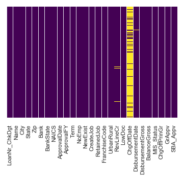

```python
sns.heatmap(dataset.isnull(),yticklabels=False,cbar=False,cmap='viridis')
```

```python
# Quick overview of all variables using pandas profiling
profile = pandas_profiling.ProfileReport(dataset)
profile.to_file(outputfile = "loanDataInfo.html")
```

**Observations:**

- Size of dataset:
  - 899164 x 27
- Summary of data types in dataset:
  - Numeric: 10 columns
  - Object: 17 columns
- The following columns contain missing values which needs to be addressed
  - **ChgOffDate:** There are 736465 missing values which accounts for 81.9% of total records. It contains date on which loan is declared to be default.
  - **RevLineCr:** There are 4528 missing values. It should contains two unique values indicating whether the type of loan is revolving line of credit or not.
  - **LowDoc:** There are 2582 missing values. It should contains two unique values indicating whether it is LowDoc loan program or not.
  - **DisbursementDate:** There are 2368 missing values. It contain dates on which loan amount got disbursed.
  - **MIS_Status:**: There are 1997 missing values. It indicates the status of loan.
  - **Bank:**: There are 1559 missing values.
  - **BankKState:** There are 1566 missing values.
  - **NewExist:**There are 136 missing values.It indicates whethere the loan is applied for new business or existing business.
  - **City, name**and **state** contains 30,14 and 14 missing values respectively.
- **ApprovalFY** denotes the year on which approval was given. Since it denotes year, it has to be a numerical column. But currently it of object type.
- **RevLineCr** and **LowDoc** are binomial variables. But it contains 18 and 8 unique values respectively. There should be only two unique values.
- **ApprovalDate** and **DisbursementDate** are of object type. But, it has to be date type.
- **CreateJob** and **RetainedJob** are highly correlated. So , RetainedJob should be ignored for analysis

**Things to do before proceeding to analysis**

```python
cleaned_dataset = dataset.drop('ChgOffDate', axis = 1)
cleaned_dataset.columns
```

```
Index(['LoanNr_ChkDgt', 'Name', 'City', 'State', 'Zip', 'Bank', 'BankState',
       'NAICS', 'ApprovalDate', 'ApprovalFY', 'Term', 'NoEmp', 'NewExist',
       'CreateJob', 'RetainedJob', 'FranchiseCode', 'UrbanRural', 'RevLineCr',
       'LowDoc', 'DisbursementDate', 'DisbursementGross', 'BalanceGross',
       'MIS_Status', 'ChgOffPrinGr', 'GrAppv', 'SBA_Appv'],
      dtype='object')
```

- **Removing records containing missing and absurd values in 'RevLineCr'column.**

```python
cleaned_dataset = cleaned_dataset[(cleaned_dataset['RevLineCr'] == 'Y') | (cleaned_dataset['RevLineCr'] == 'N')]
cleaned_dataset['RevLineCr'] = np.where(cleaned_dataset['RevLineCr'] == 'Y', 1, 0)
cleaned_dataset['RevLineCr'].unique()
```

```
array([0, 1], dtype=int64)
```

- **Converting the following columns to numeric type: DisbursementGross, BalanceGross, ChgOffPrinGr, GrAppv, SBA_Appv**

```python
cleaned_dataset['ApprovalFY'][cleaned_dataset['ApprovalFY'] == '1976A'] = '1976'
```

```python
cleaned_dataset[['DisbursementGross', 'BalanceGross', 'ChgOffPrinGr', 'GrAppv', 'SBA_Appv']] = cleaned_dataset[['DisbursementGross', 'BalanceGross', 'ChgOffPrinGr', 'GrAppv', 'SBA_Appv']].applymap(lambda x: x.strip().replace('$','').replace(',',''))
cleaned_dataset[['DisbursementGross', 'BalanceGross', 'ChgOffPrinGr', 'GrAppv', 'SBA_Appv']]
cleaned_dataset = cleaned_dataset.astype({'DisbursementGross' : 'float', 'BalanceGross':'float', 'ChgOffPrinGr':'float','GrAppv':'float','SBA_Appv':'float', 'ApprovalFY':'int64'})
cleaned_dataset.dtypes
```

```
LoanNr_ChkDgt          int64
Name                  object
City                  object
State                 object
Zip                    int64
Bank                  object
BankState             object
NAICS                  int64
ApprovalDate          object
ApprovalFY             int64
Term                   int64
NoEmp                  int64
NewExist             float64
CreateJob              int64
RetainedJob            int64
FranchiseCode          int64
UrbanRural             int64
RevLineCr              int32
LowDoc                object
DisbursementDate      object
DisbursementGross    float64
BalanceGross         float64
MIS_Status            object
ChgOffPrinGr         float64
GrAppv               float64
SBA_Appv             float64
dtype: object
```

- **Replacing missing values in the 'LowDoc' column.**

```python
def is_lowDoc(row):
    if row['GrAppv'] < 150000:
        return 'Y'
    elif row['GrAppv'] > 150000:
        return 'N'

cleaned_dataset['LowDoc'][(cleaned_dataset['LowDoc'] != 'Y') & (cleaned_dataset['LowDoc'] != 'N')] = cleaned_dataset.apply(lambda row: is_lowDoc(row), axis = 1)
```

- **Converting 'ApprovalDate' and 'DisbursementDate' to date type.**

```python
cleaned_dataset[['ApprovalDate', 'DisbursementDate']] = cleaned_dataset[['ApprovalDate', 'DisbursementDate']].apply(pd.to_datetime)
cleaned_dataset.dtypes
```

```
LoanNr_ChkDgt                 int64
Name                         object
City                         object
State                        object
Zip                           int64
Bank                         object
BankState                    object
NAICS                         int64
ApprovalDate         datetime64[ns]
ApprovalFY                    int64
Term                          int64
NoEmp                         int64
NewExist                    float64
CreateJob                     int64
RetainedJob                   int64
FranchiseCode                 int64
UrbanRural                    int64
RevLineCr                     int32
LowDoc                       object
DisbursementDate     datetime64[ns]
DisbursementGross           float64
BalanceGross                float64
MIS_Status                   object
ChgOffPrinGr                float64
GrAppv                      float64
SBA_Appv                    float64
dtype: object
```

- **Removing the remaining records containing null values**

```python
cleaned_dataset.dropna(subset = ['DisbursementDate', 'MIS_Status', 'Bank', 'BankState', 'NewExist', 'LowDoc' ,'City', 'Name', 'State'], inplace=True)
print('Null values removed')
```

```
Null values removed
```

- **Replacing '0' with mode value in 'NewExist' column**

```python
cleaned_dataset['NewExist'] = cleaned_dataset['NewExist'].replace(0.0,cleaned_dataset['NewExist'].mode()[0])
```

```python
cleaned_dataset['NewExist'].unique()
```

```
array([2., 1.])
```

- **Creating a new column 'is_franchise'**

```python
cleaned_dataset['is_franchise'] = np.where(cleaned_dataset['FranchiseCode'] == 0, 0, 1)
cleaned_dataset['is_franchise'].unique()
```

```
array([1, 0], dtype=int64)
```

- **Checking if there are still any missing values**

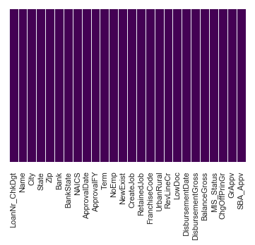

```python
sns.heatmap(cleaned_dataset.isnull(),yticklabels=False,cbar=False,cmap='viridis')
```

**Observations**

- No missing values in the dataset.

### Questions and Solutions

```python
cleaned_dataset.shape
```

```
(616051, 27)
```

- **Which financial year recorded high number of loan approvals?**

```
Text(0,0.5,'Approval counts')
```

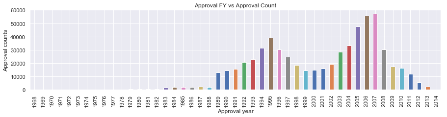

```python
plt.figure(figsize=(15,3))
cleaned_dataset.groupby('ApprovalFY')['Name'].count().plot.bar(title = "Approval FY vs Approval Count")
plt.xlabel('Approval year')
plt.ylabel('Approval counts')
```

**Observations**

- 2007 recorded high number of loan approvals. We can also observer that very less number of loan approvals fomr 1960's to 1980's and more number number of approvals from 2005-2008.
- **Which period recorded high amount of loan charge off?**

```
Text(0,0.5,'Charged off amount')
```

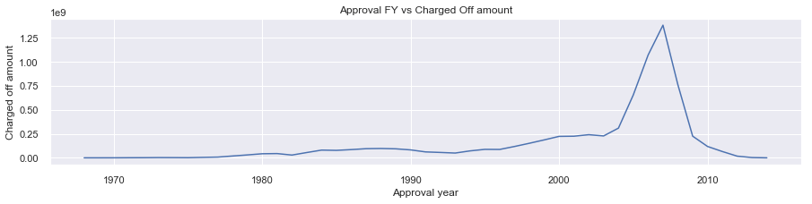

```python
plt.figure(figsize=(15,3))
cleaned_dataset.groupby('ApprovalFY')['ChgOffPrinGr'].sum().plot.line(title = "Approval FY vs Charged Off amount")
plt.xlabel('Approval year')
plt.ylabel('Charged off amount')
```

**Observations**

- Huge amount of loans were charged off during the period **2005 to 2008** which means lot of people were unable to pay the loan amount during this period.
- **Heat map to find any correlations among the variables**

```python
cleaned_dataset.shape
```

[output not shown]

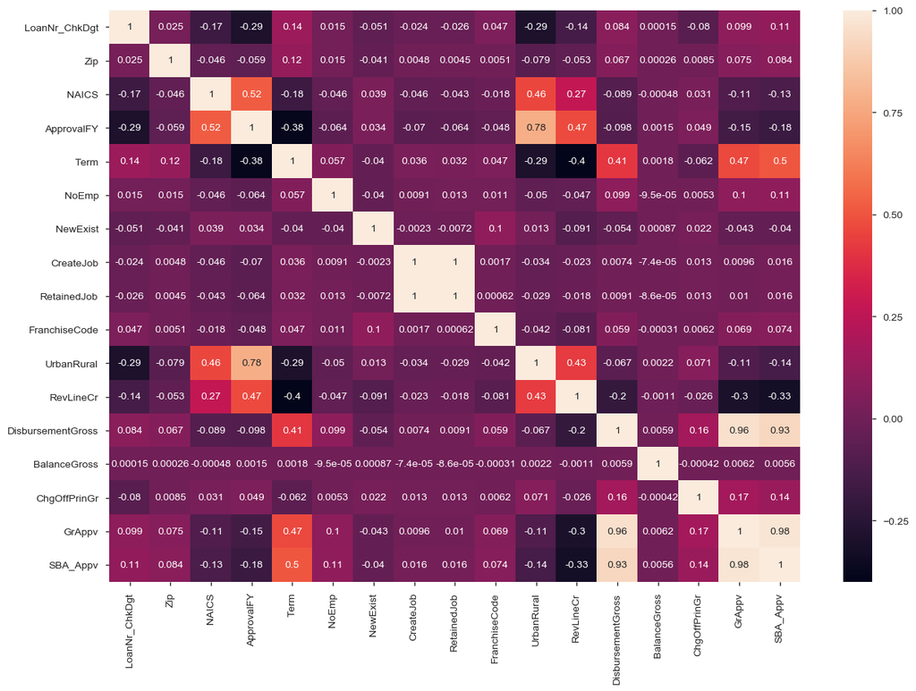

```python
plt.figure(figsize=(15,10))
corrMatrix = cleaned_dataset.corr()
sns.heatmap(corrMatrix,annot = True)
```

**Observations**

- DisbursementGross and GrAppv are highly correlated which means in most of the cases the amount disbursed is equal to amount approved.
- Create Job and Retained Job has high correlation equal to 1. 'Retained Job' should be dropped before training the model.
- **Did more number of Low Doc programs were present?**

```
Text(0.5,1,'Low Doc program vs Count')
```

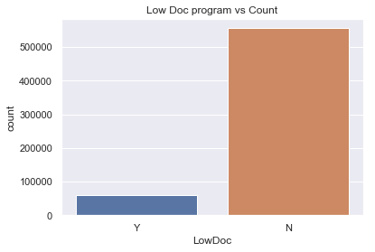

```python
plt.figure(figsize=(6,4))
sns.countplot('LowDoc', data = cleaned_dataset)
plt.title('Low Doc program vs Count')
```

**Observations**

- Almost 90% of the loans were not Low Doc program
- **Which are all the top three states where large number of jobs got created?**

```
Text(0,0.5,'No of jobs created')
```

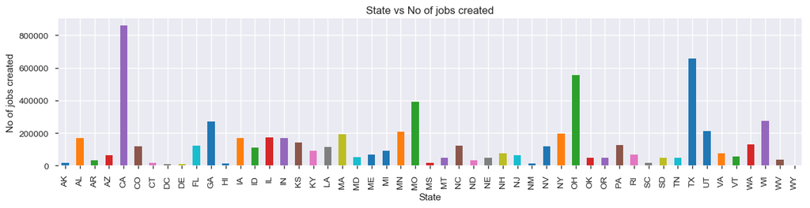

```python
plt.figure(figsize=(15,3))
cleaned_dataset.groupby('State')['CreateJob'].sum().plot.bar()
plt.title('State vs No of jobs created')
plt.ylabel('No of jobs created')
```

**Observations**

- Large number of jobs were created in California(CA), Texas(TX) and Ohio(OH).
- **Distribution of Approved amount by SBA**

```
Text(0.5,1,'Distribution of amount approved by SBA')
```

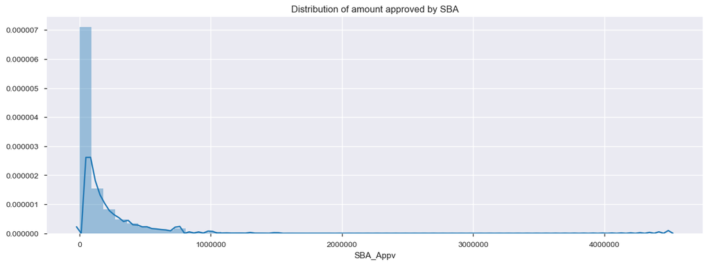

```python
plt.figure(figsize=(15,5))
sns.distplot(cleaned_dataset['SBA_Appv'])
plt.title('Distribution of amount approved by SBA')
```

**Observation**

- Most of the amount approved by SBA are less than $300000.
- **Did more loans were given for new business or existing business?**

```
Text(0.5,1,'New/Existing Business Vs Loan approval count')
```

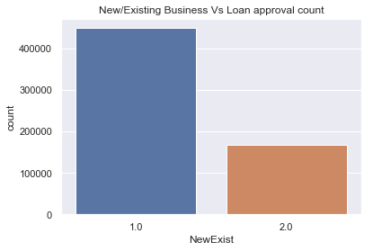

```python
plt.figure(figsize=(6,4))
sns.countplot('NewExist', data = cleaned_dataset)
plt.title('New/Existing Business Vs Loan approval count')
```

**Observations**

- Most of the loans were given for existing business.
- **Did the revolving line of credit option given to all loans?**

```
Text(0.5,1,'Revolving line of Credit vs Count')
```

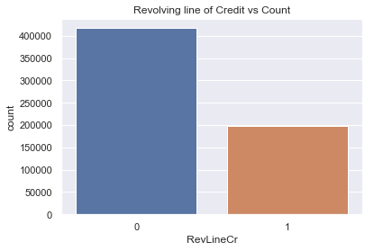

```python
plt.figure(figsize=(6,4))
sns.countplot('RevLineCr', data = cleaned_dataset)
plt.title("Revolving line of Credit vs Count")
```

**Observations**

- No, Only around 200000 loans were given revolving line of credit option.
- **Which state has more number of borrowers?**

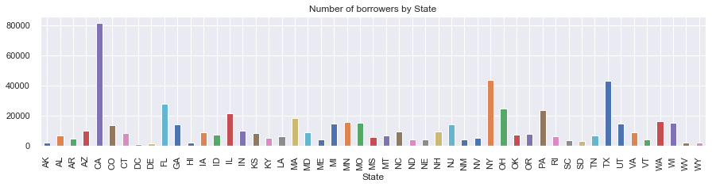

```python
plt.figure(figsize=(15,3))
cleaned_dataset.groupby('State')['Name'].count().plot.bar(title = 'Number of borrowers by State')
```

**Observations**

- More number of borrowers were from 'California (CA)'.
- **How many loans got charged off?**

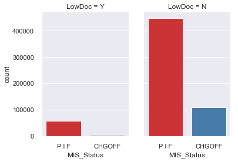

```python
sns.catplot(x="MIS_Status", col="LowDoc",
                data=cleaned_dataset, kind="count",
                height=4, aspect=.7, palette="Set1");
```

**Observations**

### Logistic Regression Model - Should loan be approved or not?

```python
from sklearn.cross_validation import train_test_split
from sklearn.linear_model import LogisticRegression
from sklearn.metrics import accuracy_score
from sklearn.metrics import confusion_matrix
from sklearn.metrics import classification_report
```

```python
cleaned_dataset['LowDoc'] = np.where(cleaned_dataset['LowDoc'] == 'Y',1,0) #Standardizing the column
ml_dataset = cleaned_dataset.drop(['LoanNr_ChkDgt','Name','State','FranchiseCode','RetainedJob','City','Zip','Bank', 'BankState', 'NAICS', 'ApprovalDate','DisbursementDate'], axis =1) #Removing uncessary columns for training the ML model
X = ml_dataset.loc[:,ml_dataset.columns != 'MIS_Status']
y = ml_dataset['MIS_Status']
X.head()
```

|  | ApprovalFY | Term | NoEmp | NewExist | CreateJob | UrbanRural | RevLineCr | LowDoc | DisbursementGross | BalanceGross | ChgOffPrinGr | GrAppv | SBA_Appv | is_franchise |
| --- | --- | --- | --- | --- | --- | --- | --- | --- | --- | --- | --- | --- | --- | --- |
| 0 | 1997 | 84 | 4 | 2.0 | 0 | 0 | 0 | 1 | 60000.0 | 0.0 | 0.0 | 60000.0 | 48000.0 | 1 |
| 1 | 1997 | 60 | 2 | 2.0 | 0 | 0 | 0 | 1 | 40000.0 | 0.0 | 0.0 | 40000.0 | 32000.0 | 1 |
| 2 | 1997 | 180 | 7 | 1.0 | 0 | 0 | 0 | 0 | 287000.0 | 0.0 | 0.0 | 287000.0 | 215250.0 | 1 |
| 3 | 1997 | 60 | 2 | 1.0 | 0 | 0 | 0 | 1 | 35000.0 | 0.0 | 0.0 | 35000.0 | 28000.0 | 1 |
| 4 | 1997 | 240 | 14 | 1.0 | 7 | 0 | 0 | 0 | 229000.0 | 0.0 | 0.0 | 229000.0 | 229000.0 | 1 |

```python
y.head()
```

```
0    P I F
1    P I F
2    P I F
3    P I F
4    P I F
Name: MIS_Status, dtype: object
```

```python
X_train, X_test, y_train, y_test = train_test_split(X, y, test_size=0.20, random_state=1)
print(X_train.shape)
print(y_train.shape)
```

```
(492840, 14)
(492840,)
```

```python
#Fitting the model with train dataset and predicting
logreg = LogisticRegression()
logreg.fit(X_train,y_train)
y_pred_train = logreg.predict(X_train)
y_pred_test = logreg.predict(X_test)
```

```python
print('Accuracy score for test data is:', accuracy_score(y_test,y_pred_test))
```

```
Accuracy score for test data is: 0.9812435577992225
```

```python
print('Accuracy score for train data is:', accuracy_score(y_train,y_pred_train))
```

```
Accuracy score for train data is: 0.9813834104374645
```

```python
confusion_matrix = pd.DataFrame(confusion_matrix(y_test, y_pred_test))
print(confusion_matrix)
```

```
       0       1
0  20644    1899
1    412  100256
```

**Observation**

- The model has 98% accuracy score.
- It has **120900** correct predictions and **2311** incorrect predictions.
- **Classification Report**

```python
print(classification_report(y_test,y_pred_test))
```

```
             precision    recall  f1-score   support

     CHGOFF       0.98      0.92      0.95     22543
      P I F       0.98      1.00      0.99    100668

avg / total       0.98      0.98      0.98    123211
```